# Multiome tutorial - MultiAssayExperiment

Xiaosai Yao

September 4th, 2022

#### Package

epiregulon 1.0.14

# 1 Introduction

This tutorial walks through the same dataset used in the “multiome tutorial - archR workflow”. This is a dataset generated by infecting LNCaP cells with NKX2-1 and GATA6 to examine the effects of these TFs on AR activity.

# 2 Installation

Epiregulon is currently available on R/dev

```r
library(epiregulon)
```

Alternatively, you could install from gitlab

```r
devtools::install_gitlab(repo='scwg/gene-transcriptional-network/activity-inference/Epiregulon',
                         auth_token = "<gitlab token>",
                         host = "https://code.roche.com/" )

library(epiregulon)
```

# 3 Data preparation

Single cell preprocessing needs to performed by user’s favorite methods prior to using Epiregulon. The following components are required:  
1. Peak matrix from scATAC-seq  
2. Gene expression matrix from either paired or unpaired scRNA-seq. RNA-seq integration needs to be performed for unpaired dataset.  
3. Dimensionality reduction matrix from with either single modalities or joint scRNA-seq and scATAC-seq

Multiome data can now be conveniently processed by `initiate.archr` and then `gp.sa.archr` to obtain peak matrices. Finally, the archR project can be uploaded into DatasetDB as a MultiAssayExperiment object using `maw.archr::importArchr` or `maw.archr::create.mae.with.multiple.sces.from.archr`

```r
# load the MAE object
library(SingleCellExperiment)
mae <- dsassembly::getDataset("DS000013080")
```

[output not shown]

```r
# peak matrix
PeakMatrix <- mae[["PeakMatrix"]]
rownames(PeakMatrix) <- rowData(PeakMatrix)$idx

# expression matrix
GeneExpressionMatrix <- mae[["GeneExpressionMatrix"]]
rownames(GeneExpressionMatrix) <- rowData(GeneExpressionMatrix)$name

# dimensional reduction matrix
reducedDimMatrix <- reducedDim(mae[['TileMatrix500']], "LSI_ATAC")
```

Visualize singleCellExperiment by UMAP

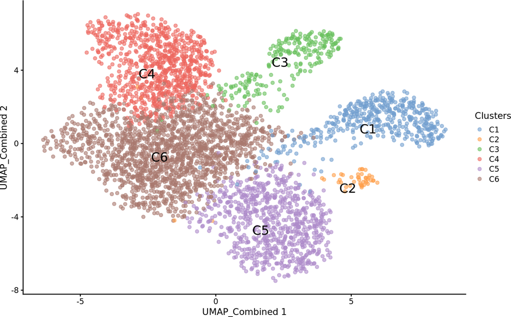

```r
# transfer UMAP_combined from TileMatrix to GeneExpressionMatrix
reducedDim(GeneExpressionMatrix, "UMAP_Combined") <- reducedDim(mae[['TileMatrix500']], "UMAP_Combined")
scater::plotReducedDim(GeneExpressionMatrix,
                       dimred = "UMAP_Combined",
                       text_by = "Clusters",
                       colour_by = "Clusters")
```

# 4 Quick start

## 4.1 Retrieve bulk TF ChIP-seq binding sites

First, we retrieve the information of TF binding sites collected from Cistrome and ENCODE ChIP-seq, which are hosted on Genomitory. Currently, human genomes HG19 and HG38 and mouse mm10 are available.

```r
grl <- getTFMotifInfo(genome = "hg38")
```

```
#> redirecting from 'GMTY162:hg38_motif_bed_granges@REVISION-3' to 'GMTY162:hg38_motif_bed_granges@80bc58c4783ce8ceedc6fde61e2b2ebfe50869f7'
```

```r
head(grl)
```

```
#> GRangesList object of length 6:
#> $ADNP
#> GRanges object with 20545 ranges and 0 metadata columns:
#>           seqnames              ranges strand
#>              <Rle>           <IRanges>  <Rle>
#>       [1]     chr1       629819-630076      *
#>       [2]     chr1       633892-634164      *
#>       [3]     chr1       960443-960765      *
#>       [4]     chr1     1011312-1012144      *
#>       [5]     chr1     1058025-1058347      *
#>       ...      ...                 ...    ...
#>   [20541]     chrX 154136551-154137792      *
#>   [20542]     chrX 154501525-154502608      *
#>   [20543]     chrX 154751612-154752444      *
#>   [20544]     chrX 155069184-155070016      *
#>   [20545]     chrX 155218440-155219571      *
#>   -------
#>   seqinfo: 25 sequences from an unspecified genome; no seqlengths
#>
#> ...
#> <5 more elements>
```

## 4.2 Link ATAC-seq peaks to target genes

Next, we compute peak to gene correlations using a custom algorithm that has similar performance to ArchR’s P2G function.

```r
p2g <- calculateP2G(peakMatrix = PeakMatrix,
                    expMatrix = GeneExpressionMatrix,
                    reducedDim = reducedDimMatrix)
```

```
#> Using epiregulon to compute peak to gene links...
#> performing k means clustering to form metacells
#> Computing correlation
```

```r
head(p2g)
```

```
#>     idxATAC  chr  start    end idxRNA     target Correlation        FDR
#> 132       2 chr1 818831 819331     21 AL645608.2   0.5143010 0.39174372
#> 10        4 chr1 827287 827787     15  LINC01409   0.6029940 0.19109407
#> 33        5 chr1 858735 859235     17  LINC01128   0.5713281 0.25699621
#> 679      10 chr1 920987 921487     33       AGRN   0.5173568 0.38425537
#> 218      12 chr1 924540 925040     23  LINC02593   0.7378571 0.02515392
#> 219      13 chr1 925135 925635     23  LINC02593   0.7218096 0.03498983
```

## 4.3 Add TF motif binding to peaks

The next step is to add the TF binding information by overlapping regions of the peak matrix with the bulk chip-seq database loaded in 2. The user can supply either an archR project path and this function will retrieve the peak matrix, or a peakMatrix in the form of a Granges object or RangedSummarizedExperiment.

```r
overlap <- addTFMotifInfo(grl = grl, p2g = p2g, peakMatrix = PeakMatrix)
```

```
#> Computing overlap...
#> Success!
```

```r
head(overlap)
```

```
#>    idxATAC idxTF              tf
#> 56       2    12              AR
#> 57       2   385           KLF15
#> 58       2   542           NR3C1
#> 59       2   576             PGR
#> 60       2   597 POLR2AphosphoS5
#> 63       4    12              AR
```

## 4.4 Generate regulons

- tf (transcription factor)
- target gene
- peak to gene correlation between tf and target gene

```r
regulon <- getRegulon(p2g = p2g, overlap = overlap, aggregate = FALSE)
head(regulon)
```

```
#>   idxATAC idxTF              tf  chr  start    end idxRNA     target     corr
#> 1       2    12              AR chr1 818831 819331     21 AL645608.2 0.514301
#> 2       2   385           KLF15 chr1 818831 819331     21 AL645608.2 0.514301
#> 3       2   542           NR3C1 chr1 818831 819331     21 AL645608.2 0.514301
#> 4       2   576             PGR chr1 818831 819331     21 AL645608.2 0.514301
#> 5       2   597 POLR2AphosphoS5 chr1 818831 819331     21 AL645608.2 0.514301
#> 6       4    12              AR chr1 827287 827787     15  LINC01409 0.602994
#>         FDR
#> 1 0.3917437
#> 2 0.3917437
#> 3 0.3917437
#> 4 0.3917437
#> 5 0.3917437
#> 6 0.1910941
```

## 4.5 Network pruning (highly recommended)

```r
pruned.regulon <- calculateJointProbability(expMatrix = GeneExpressionMatrix,
                                       exp_assay = "counts",
                                       peakMatrix = PeakMatrix,
                                       peak_assay = "counts",
                                       regulon = regulon[regulon$tf %in%
                                                      c("NKX2-1","GATA6","FOXA1","FOXA2", "AR","SOX2"),],
                                       clusters = GeneExpressionMatrix$Clusters,
                                       exp_cutoff = 0.5,
                                       peak_cutoff = 0)
```

## 4.6 Add Weights

```r
regulon.w <- addWeights(regulon = pruned.regulon,
                        sce = GeneExpressionMatrix,
                        cluster_factor = "Clusters",
                        exprs_values = "counts",
                        block_factor = NULL,
                        corr = TRUE,
                        MI = FALSE,
                        BPPARAM = BiocParallel::MulticoreParam())
```

```r
head(regulon.w)
```

```
#>    tf target         all          C1 C2          C3          C4          C5
#> 12 AR  AAGAB 0.011529593 0.020361991  0 0.009049774 0.011111111 0.009162304
#> 16 AR   AAK1 0.012554445 0.015837104  0 0.022624434 0.008641975 0.005235602
#> 19 AR  AAMDC 0.001024853 0.004524887  0 0.000000000 0.000000000 0.000000000
#> 24 AR   AATF 0.005636690 0.011312217  0 0.000000000 0.004115226 0.008289703
#> 29 AR ABALON 0.002049705 0.000000000  0 0.018099548 0.002469136 0.001308901
#> 33 AR   ABAT 0.001793492 0.002262443  0 0.009049774 0.004938272 0.000000000
#>             C6      weight
#> 12 0.011111111 -0.60605052
#> 16 0.016049383 -0.14260301
#> 19 0.001234568  0.04598338
#> 24 0.004526749  0.19643948
#> 29 0.000617284  0.13626563
#> 33 0.000000000  0.83495618
```

## 4.7 Calculate TF activity

Finally, the activities for a specific TF in each cell are computed by averaging expressions of target genes linked to the TF weighted by the correlation variable of user’s choice.
$$y=\frac{1}{n}\sum_{i=1}^{n} x_i * corr_i$$
where $y$ is the activity of a TF for a cell $n$ is the total number of targets for a TF $x_i$ is the log count expression of target i where i in {1,2,…,n} $corr_i$ is the weight of TF and target i

```r
score.combine <- calculateActivity(sce = GeneExpressionMatrix,
                                   regulon = regulon.w,
                                   mode = "weight",
                                   method = "weightedMean",
                                   assay = "counts")
```

```
#> calculating TF activity from regulon using weightedmean
```

## 4.8 Perform differential activity

```r
markers <- findDifferentialActivity(activity_matrix = score.combine,
                                    groups = GeneExpressionMatrix$Clusters,
                                    pval.type = "some",
                                    direction = "up",
                                    test.type = "t")
```

Take the top TFs

```r
markers.sig <- getSigGenes(markers, topgenes = 5 )
```

```
#> Using a logFC cutoff of 0.7 for class C1
#> Using a logFC cutoff of -0.1 for class C2
#> Using a logFC cutoff of 0.5 for class C3
#> Using a logFC cutoff of 0.3 for class C4
#> Using a logFC cutoff of 0.1 for class C5
#> Using a logFC cutoff of 0.9 for class C6
```

## 4.9 Visualize the results

First visualize the known differential TFs by bubble plot

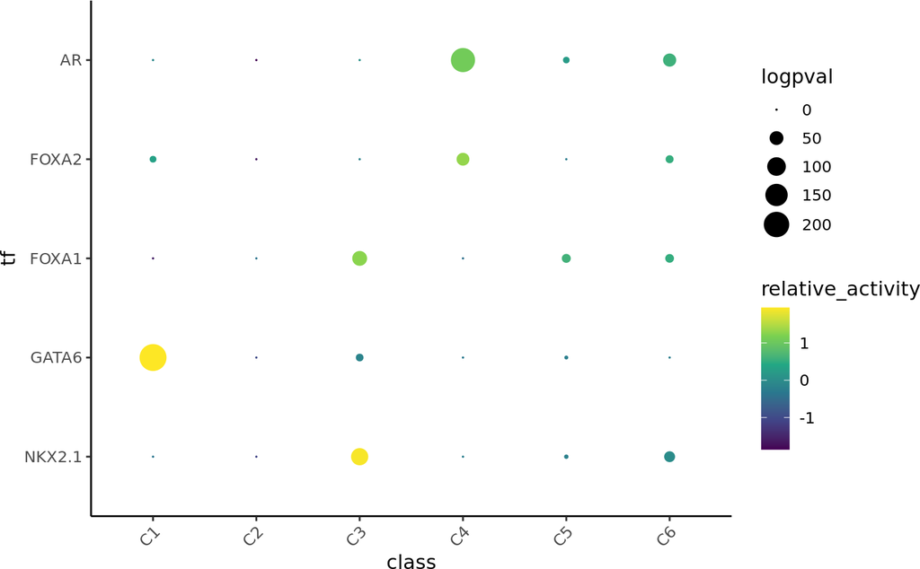

```r
plotBubble(activity_matrix = score.combine,
           tf = c("NKX2-1","GATA6","FOXA1","FOXA2", "AR"),
           class = GeneExpressionMatrix$Clusters)
```

Then visualize the most differential TFs by clusters

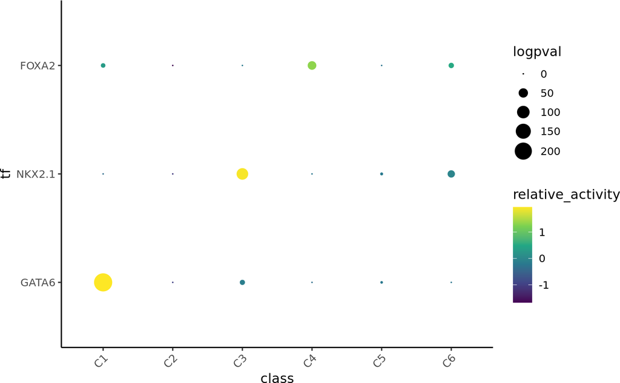

```r
plotBubble(activity_matrix = score.combine,
           tf = markers.sig$tf,
           class = GeneExpressionMatrix$Clusters)
```

Visualize the known differential TFs by violin plot. Note there is no activity calculated for SOX2 because the expression of SOX2 is 0 in all cells.

```
#> SOX2 not found in activity matrix. Excluded from plots
```

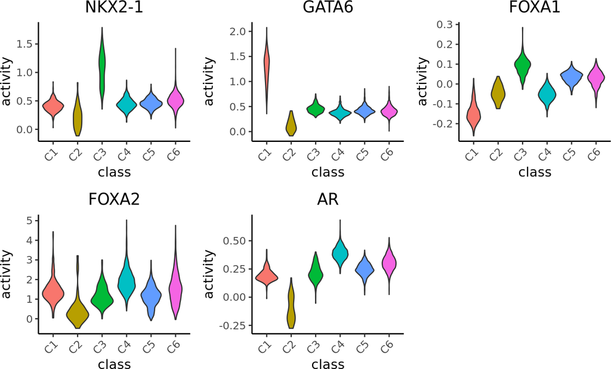

```r
plotActivityViolin(activity_matrix = score.combine,
                   tf = c("NKX2-1","GATA6","FOXA1","FOXA2", "AR", "SOX2"),
                   class = GeneExpressionMatrix$Clusters)
```

Visualize the known differential TFs by UMAP

```
#> SOX2 not found in activity matrix. Excluded from plots
```

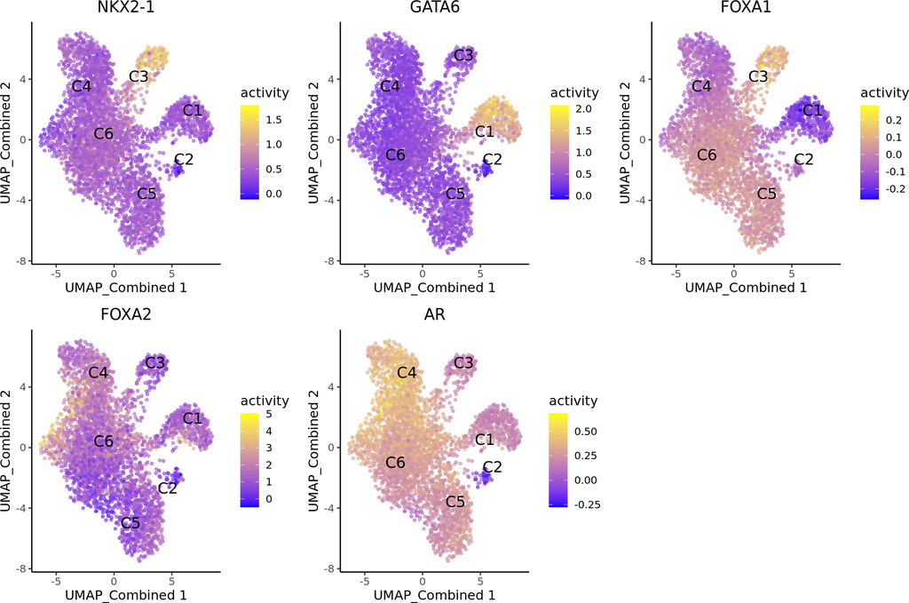

```r
plotActivityDim(sce = GeneExpressionMatrix, activity_matrix=score.combine,
                tf = c("NKX2-1","GATA6","FOXA1","FOXA2", "AR", "SOX2"),
                dimtype = "UMAP_Combined",
                label = "Clusters",
                point_size=1,
                ncol = 3)
```

## 4.10 Geneset enrichment

Sometimes we are interested to know what pathways are enriched in the regulon of a particular TF. We can perform geneset enrichment using the enricher function from [clusterProfiler](http://yulab-smu.top/biomedical-knowledge-mining-book/universal-api.html).

```r
#retrieve genesets
H <- EnrichmentBrowser::getGenesets(org = "hsa", db = "msigdb", cat = "H",
                                    gene.id.type = "SYMBOL" )
```

```
#> Using cached version from 2022-09-29 16:49:42
```

```r
C6 <- EnrichmentBrowser::getGenesets(org = "hsa", db = "msigdb", cat = "C6",
                                     gene.id.type = "SYMBOL" )
```

```
#> Using cached version from 2022-09-29 16:49:46
```

```r
#combine genesets and convert genesets to be compatible with enricher
gs <- c(H,C6)
gs.list <- do.call(rbind,lapply(names(gs), function(x)
  {data.frame(gs=x, genes=gs[[x]])}))

enrichresults <- regulonEnrich(TF = c("GATA6","AR"),
                               regulon = regulon.w,
                               corr = "weight",
                               corr_cutoff = 0.5,
                               genesets = gs.list)
```

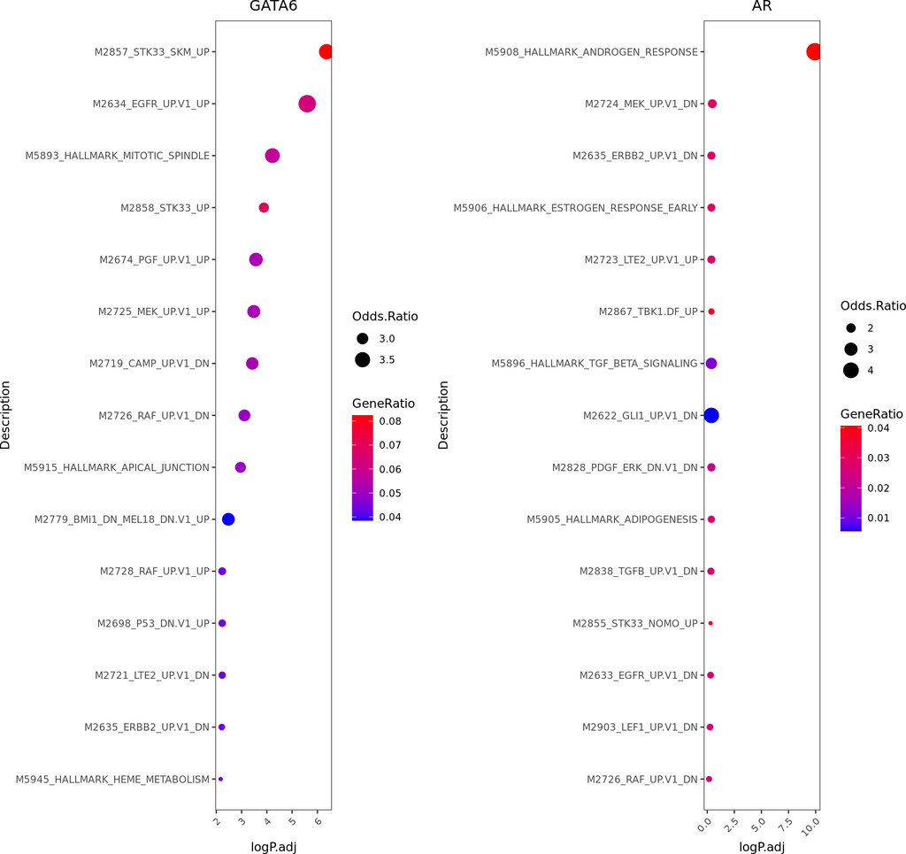

```r
#plot results
enrichPlot(results = enrichresults)
```

## Network analysis

We can visualize the genesets as a network

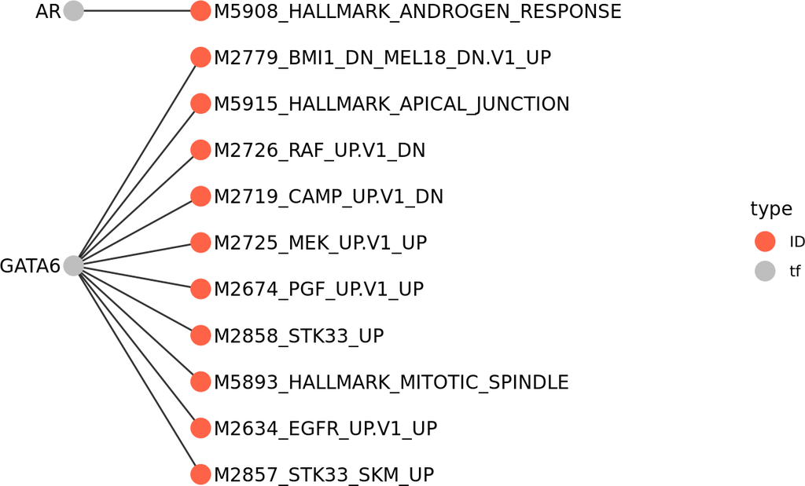

```r
plotGseaNetwork(tf = names(enrichresults),
                enrichresults = enrichresults,
                p.adj_cutoff = 0.1,
                ntop_pathways = 10)
```

## 4.11 Differential networks

We can calculate joint probabilities for every cluster

```r
differential.regulon <- calculateJointProbability(expMatrix = GeneExpressionMatrix,
                                       exp_assay = "counts",
                                       peakMatrix = PeakMatrix,
                                       peak_assay = "counts",
                                       regulon = regulon[regulon$tf %in%
                                                        c("NKX2-1","GATA6","FOXA1","FOXA2", "AR","SOX2"),],
                                       clusters = GeneExpressionMatrix$Clusters,
                                       exp_cutoff = 0.5,
                                       peak_cutoff = 0)
```

```
#> compute joint probability for all trios
```

```r
head(differential.regulon)
```

```
#>        tf target          all          C1 C2          C3          C4
#> 12     AR  AAGAB 0.0115295926 0.020361991  0 0.009049774 0.011111111
#> 13  FOXA1  AAGAB 0.0020497054 0.006787330  0 0.000000000 0.002469136
#> 15  GATA6  AAGAB 0.0010248527 0.009049774  0 0.000000000 0.000000000
#> 16     AR   AAK1 0.0125544453 0.015837104  0 0.022624434 0.008641975
#> 17  FOXA1   AAK1 0.0053804766 0.004524887  0 0.009049774 0.003703704
#> 18 NKX2-1   AAK1 0.0002562132 0.000000000  0 0.004524887 0.000000000
#>             C5          C6
#> 12 0.009162304 0.011111111
#> 13 0.001308901 0.001234568
#> 15 0.000000000 0.000000000
#> 16 0.005235602 0.016049383
#> 17 0.001308901 0.008024691
#> 18 0.000000000 0.000000000
```